# Case Study 1

Blake Freeman & Neddy Nyatome

Introduction:

Today we will go over the results of the questions that you requested and addtional insights that I discovered during my exploration of this data. With that being said lets dive right in and go over the findings.

#dependencys

```r
library(tidyverse)
library(class)
library(caret)
```

```r
library(e1071)
library(ggplot2)
```

#Import the files

```r
beers_df = read.csv("C:/Users/blake/Desktop/MSDS/Case/CaseStudy1/Data/Beers.csv",header = TRUE,stringsAsFactors=FALSE)

breweries_df = read.csv("C:/Users/blake/Desktop/MSDS/Case/CaseStudy1/Data/Breweries.csv",header = TRUE,stringsAsFactors=FALSE)
```

#Beer Data look.

```r
beers_df
```

| Name | Beer_ID | ABV | IBU | Brewery_id | Style | Ounces |
| --- | --- | --- | --- | --- | --- | --- |
| Pub Beer | 1436 | 0.050 | NA | 409 | American Pale Lager | 12.0 |
| Devil's Cup | 2265 | 0.066 | NA | 178 | American Pale Ale (APA) | 12.0 |
| Rise of the Phoenix | 2264 | 0.071 | NA | 178 | American IPA | 12.0 |
| Sinister | 2263 | 0.090 | NA | 178 | American Double / Imperial IPA | 12.0 |
| Sex and Candy | 2262 | 0.075 | NA | 178 | American IPA | 12.0 |
| Black Exodus | 2261 | 0.077 | NA | 178 | Oatmeal Stout | 12.0 |
| Lake Street Express | 2260 | 0.045 | NA | 178 | American Pale Ale (APA) | 12.0 |
| Foreman | 2259 | 0.065 | NA | 178 | American Porter | 12.0 |
| Jade | 2258 | 0.055 | NA | 178 | American Pale Ale (APA) | 12.0 |
| Cone Crusher | 2131 | 0.086 | NA | 178 | American Double / Imperial IPA | 12.0 |

[output cut: 2400 more lines]

This was an initail look at the beer data. The type of data shows Name of the beer, Beer ID, ABV,IBU Brewery ID Style and how many ounces each beer contains.

#Brewery data

```r
breweries_df
```

| Brew_ID | Name | City | State |
| --- | --- | --- | --- |
| 1 | NorthGate Brewing | Minneapolis | MN |
| 2 | Against the Grain Brewery | Louisville | KY |
| 3 | Jack's Abby Craft Lagers | Framingham | MA |
| 4 | Mike Hess Brewing Company | San Diego | CA |
| 5 | Fort Point Beer Company | San Francisco | CA |
| 6 | COAST Brewing Company | Charleston | SC |
| 7 | Great Divide Brewing Company | Denver | CO |
| 8 | Tapistry Brewing | Bridgman | MI |
| 9 | Big Lake Brewing | Holland | MI |
| 10 | The Mitten Brewing Company | Grand Rapids | MI |

[output cut: 548 more lines]

This was an initail look at the Brewery data. The type of data shows the Name of the brewery, City and State. When reviewing this Data I noticed there were duplicate values proceeded in the process of removing these data points from the Values.

#Checking to see if there is duplicated Values and removing them.

```r
#duplicated(breweries_df$Name)
breweries_df <- breweries_df[!duplicated(breweries_df$Name), ]
breweries_df
```

|  | Brew_ID | Name | City | State |
| --- | --- | --- | --- | --- |
| 1 | 1 | NorthGate Brewing | Minneapolis | MN |
| 2 | 2 | Against the Grain Brewery | Louisville | KY |
| 3 | 3 | Jack's Abby Craft Lagers | Framingham | MA |
| 4 | 4 | Mike Hess Brewing Company | San Diego | CA |
| 5 | 5 | Fort Point Beer Company | San Francisco | CA |
| 6 | 6 | COAST Brewing Company | Charleston | SC |
| 7 | 7 | Great Divide Brewing Company | Denver | CO |
| 8 | 8 | Tapistry Brewing | Bridgman | MI |
| 9 | 9 | Big Lake Brewing | Holland | MI |
| 10 | 10 | The Mitten Brewing Company | Grand Rapids | MI |

[output cut: 541 more lines]

On futher exploration on the Brewery Data I checked to see if we had duplicated values in the Name category. I noticed that there were some values duplicated and removed these from the Brewery Data set. Based on my check there were a total of 7 Duplicated Values.

```r
#duplicated(beers_df$Name)
beers_df <- beers_df[!duplicated(beers_df$Name), ]
beers_df
```

|  | Name | Beer_ID | ABV | IBU | Brewery_id | Style | Ounces |
| --- | --- | --- | --- | --- | --- | --- | --- |
| 1 | Pub Beer | 1436 | 0.050 | NA | 409 | American Pale Lager | 12.0 |
| 2 | Devil's Cup | 2265 | 0.066 | NA | 178 | American Pale Ale (APA) | 12.0 |
| 3 | Rise of the Phoenix | 2264 | 0.071 | NA | 178 | American IPA | 12.0 |
| 4 | Sinister | 2263 | 0.090 | NA | 178 | American Double / Imperial IPA | 12.0 |
| 5 | Sex and Candy | 2262 | 0.075 | NA | 178 | American IPA | 12.0 |
| 6 | Black Exodus | 2261 | 0.077 | NA | 178 | Oatmeal Stout | 12.0 |
| 7 | Lake Street Express | 2260 | 0.045 | NA | 178 | American Pale Ale (APA) | 12.0 |
| 8 | Foreman | 2259 | 0.065 | NA | 178 | American Porter | 12.0 |
| 9 | Jade | 2258 | 0.055 | NA | 178 | American Pale Ale (APA) | 12.0 |
| 10 | Cone Crusher | 2131 | 0.086 | NA | 178 | American Double / Imperial IPA | 12.0 |

[output cut: 2295 more lines]

On futher exploration on the Beer Data I checked to see if we had duplicated values in the Name category. We noticed that there were some values duplicated and removed these from the Beer Data set. There was a total of 105 rows removed from the Beer Data set from the first pass

```r
#find all the values that have () in them
x = ")"
beers <- beers_df %>%
  filter(
str_detect(beers_df$Name, fixed(x)))

#List of all the beers I want to keep
Beers_to_keep <- beers %>%
  distinct(ABV, IBU, Style, Ounces, .keep_all = TRUE)


#Turn the beers I want to keep into a List
list_beer <- as.list(Beers_to_keep$Name)

#Filter out the beers and set a dataframe to drop
beers_to_drop <- beers[ ! beers$Name %in% list_beer, ]
#Create a list to drop from my main dataframe
beers_to_drop_list<- as.list(beers_to_drop$Name)


beers_df <-beers_df[ ! beers_df$Name %in% beers_to_drop_list, ]
beers_df
```

|  | Name | Beer_ID | ABV | IBU | Brewery_id | Style | Ounces |
| --- | --- | --- | --- | --- | --- | --- | --- |
| 1 | Pub Beer | 1436 | 0.050 | NA | 409 | American Pale Lager | 12.0 |
| 2 | Devil's Cup | 2265 | 0.066 | NA | 178 | American Pale Ale (APA) | 12.0 |
| 3 | Rise of the Phoenix | 2264 | 0.071 | NA | 178 | American IPA | 12.0 |
| 4 | Sinister | 2263 | 0.090 | NA | 178 | American Double / Imperial IPA | 12.0 |
| 5 | Sex and Candy | 2262 | 0.075 | NA | 178 | American IPA | 12.0 |
| 6 | Black Exodus | 2261 | 0.077 | NA | 178 | Oatmeal Stout | 12.0 |
| 7 | Lake Street Express | 2260 | 0.045 | NA | 178 | American Pale Ale (APA) | 12.0 |
| 8 | Foreman | 2259 | 0.065 | NA | 178 | American Porter | 12.0 |
| 9 | Jade | 2258 | 0.055 | NA | 178 | American Pale Ale (APA) | 12.0 |
| 10 | Cone Crusher | 2131 | 0.086 | NA | 178 | American Double / Imperial IPA | 12.0 |

[output cut: 2240 more lines]

On review there was another duplication that was discovered in the Data. We noticed that some beers are duplicated but have a slightly diffrent name with the year in () at the end of the beers name. Since those values were the same we decided to remove these since they are the same beer in all other aspects other than name and beer id. The code above is how we addressed that issue.

#Addressing the Null Values

```r
library(dplyr)

beers_df[is.na(beers_df)] <- 0
beers_df
```

|  | Name | Beer_ID | ABV | IBU | Brewery_id | Style | Ounces |
| --- | --- | --- | --- | --- | --- | --- | --- |
| 1 | Pub Beer | 1436 | 0.050 | 0 | 409 | American Pale Lager | 12.0 |
| 2 | Devil's Cup | 2265 | 0.066 | 0 | 178 | American Pale Ale (APA) | 12.0 |
| 3 | Rise of the Phoenix | 2264 | 0.071 | 0 | 178 | American IPA | 12.0 |
| 4 | Sinister | 2263 | 0.090 | 0 | 178 | American Double / Imperial IPA | 12.0 |
| 5 | Sex and Candy | 2262 | 0.075 | 0 | 178 | American IPA | 12.0 |
| 6 | Black Exodus | 2261 | 0.077 | 0 | 178 | Oatmeal Stout | 12.0 |
| 7 | Lake Street Express | 2260 | 0.045 | 0 | 178 | American Pale Ale (APA) | 12.0 |
| 8 | Foreman | 2259 | 0.065 | 0 | 178 | American Porter | 12.0 |
| 9 | Jade | 2258 | 0.055 | 0 | 178 | American Pale Ale (APA) | 12.0 |
| 10 | Cone Crusher | 2131 | 0.086 | 0 | 178 | American Double / Imperial IPA | 12.0 |

[output cut: 2240 more lines]

I replaced all Null values with zero in the beer data. I did this since removing these values will skew the data. I felt it was approprate to still count the beers accordingly when displaying their values.

#Number of Breweries by State

```r
breweries_by_state <- breweries_df %>% group_by(State) %>% tally()
breweries_by_state
```

| State | n |
| --- | --- |
| AK | 7 |
| AL | 3 |
| AR | 2 |
| AZ | 11 |
| CA | 39 |
| CO | 46 |
| CT | 8 |
| DC | 1 |
| DE | 2 |
| FL | 15 |

[output cut: 41 more lines]

Tally count of Breweries to create a data for a visualization to show the count of breweries per state.

#Number of Breweries by State Visulation

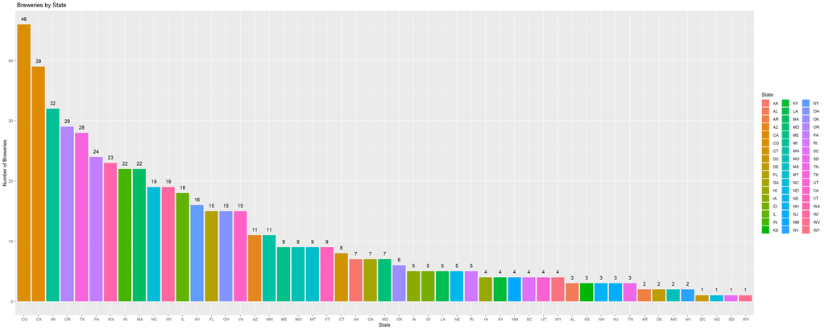

```r
g <- ggplot(breweries_by_state, aes(x = reorder(State,-n),y = n, fill =State)) + geom_bar(stat = "identity")+ geom_text(aes(label = n), vjust=-1) + labs(title =" Breweries by State", x = "State", y = "Number of Breweries")

g
```

Colorado has the highest Breweries than any other state with 46 breweries in the State. This is displayed in the Graph above.

#Merged the Dataframe’s

```r
beer_breweries_df <- merge(breweries_df,beers_df, by.x=c("Brew_ID"), by.y=c("Brewery_id"))
beer_breweries_df
```

| Brew_ID | Name.x | City | State | Name.y | Beer_ID | ABV | IBU | Style | Ounces |
| --- | --- | --- | --- | --- | --- | --- | --- | --- | --- |
| 1 | NorthGate Brewing | Minneapolis | MN | Parapet ESB | 2687 | 0.056 | 47 | Extra Special / Strong Bitter (ESB) | 16.0 |
| 1 | NorthGate Brewing | Minneapolis | MN | Wall's End | 2690 | 0.048 | 19 | English Brown Ale | 16.0 |
| 1 | NorthGate Brewing | Minneapolis | MN | Stronghold | 2688 | 0.060 | 25 | American Porter | 16.0 |
| 1 | NorthGate Brewing | Minneapolis | MN | Pumpion | 2689 | 0.060 | 38 | Pumpkin Ale | 16.0 |
| 1 | NorthGate Brewing | Minneapolis | MN | Maggie's Leap | 2691 | 0.049 | 26 | Milk / Sweet Stout | 16.0 |
| 1 | NorthGate Brewing | Minneapolis | MN | Get Together | 2692 | 0.045 | 50 | American IPA | 16.0 |
| 2 | Against the Grain Brewery | Louisville | KY | Bloody Show | 2679 | 0.055 | 17 | American Pilsner | 16.0 |
| 2 | Against the Grain Brewery | Louisville | KY | Flesh Gourd'n | 2681 | 0.066 | 21 | Pumpkin Ale | 16.0 |
| 2 | Against the Grain Brewery | Louisville | KY | Kamen Knuddeln | 2676 | 0.065 | 0 | American Wild Ale | 16.0 |
| 2 | Against the Grain Brewery | Louisville | KY | Sho'nuff | 2680 | 0.040 | 13 | Belgian Pale Ale | 16.0 |

[output cut: 2215 more lines]

```r
head(beer_breweries_df)
```

|  | Brew_ID | Name.x | City | State | Name.y | Beer_ID | ABV | IBU | Style | Ounces |
| --- | --- | --- | --- | --- | --- | --- | --- | --- | --- | --- |
| 1 | 1 | NorthGate Brewing | Minneapolis | MN | Parapet ESB | 2687 | 0.056 | 47 | Extra Special / Strong Bitter (ESB) | 16 |
| 2 | 1 | NorthGate Brewing | Minneapolis | MN | Wall's End | 2690 | 0.048 | 19 | English Brown Ale | 16 |
| 3 | 1 | NorthGate Brewing | Minneapolis | MN | Stronghold | 2688 | 0.060 | 25 | American Porter | 16 |
| 4 | 1 | NorthGate Brewing | Minneapolis | MN | Pumpion | 2689 | 0.060 | 38 | Pumpkin Ale | 16 |
| 5 | 1 | NorthGate Brewing | Minneapolis | MN | Maggie's Leap | 2691 | 0.049 | 26 | Milk / Sweet Stout | 16 |
| 6 | 1 | NorthGate Brewing | Minneapolis | MN | Get Together | 2692 | 0.045 | 50 | American IPA | 16 |

```r
tail(beer_breweries_df)
```

|  | Brew_ID | Name.x | City | State | Name.y | Beer_ID | ABV | IBU | Style | Ounces |
| --- | --- | --- | --- | --- | --- | --- | --- | --- | --- | --- |
| 2220 | 556 | Ukiah Brewing Company | Ukiah | CA | Pilsner Ukiah | 98 | 0.055 | 0 | German Pilsener | 12 |
| 2221 | 557 | Butternuts Beer and Ale | Garrattsville | NY | Moo Thunder Stout | 50 | 0.049 | 0 | Milk / Sweet Stout | 12 |
| 2222 | 557 | Butternuts Beer and Ale | Garrattsville | NY | Snapperhead IPA | 51 | 0.068 | 0 | American IPA | 12 |
| 2223 | 557 | Butternuts Beer and Ale | Garrattsville | NY | Porkslap Pale Ale | 49 | 0.043 | 0 | American Pale Ale (APA) | 12 |
| 2224 | 557 | Butternuts Beer and Ale | Garrattsville | NY | Heinnieweisse Weissebier | 52 | 0.049 | 0 | Hefeweizen | 12 |
| 2225 | 558 | Sleeping Lady Brewing Company | Anchorage | AK | Urban Wilderness Pale Ale | 30 | 0.049 | 0 | English Pale Ale | 12 |

#Median ABV and IBU

```r
library(plyr)
ABV_Median<- ddply(beer_breweries_df,~State,summarise,Median_ABV = median(ABV))
IBU_Median<- ddply(beer_breweries_df,~State,summarise,Median_IBU = median(IBU))
ABV_Median
```

| State | Median_ABV |
| --- | --- |
| AK | 0.0560 |
| AL | 0.0600 |
| AR | 0.0520 |
| AZ | 0.0550 |
| CA | 0.0580 |
| CO | 0.0580 |
| CT | 0.0605 |
| DC | 0.0625 |
| DE | 0.0275 |
| FL | 0.0550 |

[output cut: 41 more lines]

```r
IBU_Median
```

| State | Median_IBU |
| --- | --- |
| AK | 17.0 |
| AL | 39.5 |
| AR | 0.0 |
| AZ | 12.0 |
| CA | 28.0 |
| CO | 13.0 |
| CT | 0.0 |
| DC | 5.5 |
| DE | 26.0 |
| FL | 21.0 |

[output cut: 41 more lines]

#Plotted ABV Median and IBU

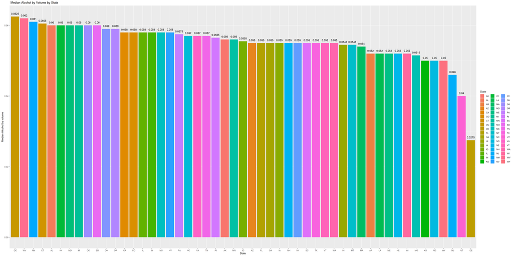

```r
library(ggplot2)

g <- ggplot(ABV_Median, aes(x = reorder(State,-Median_ABV),y = Median_ABV, fill =State)) + geom_bar(stat = "identity")+ geom_text(aes(label = Median_ABV), vjust=-1) + labs(title =" Median Alcohol by Volume by State", x = "State", y = "Median Alcohol by volume")
g
```

DC has the highest median alcohol content per volume then any other state at .0625 (6.25%). This is displayed by the graph above.

#Plotted ABV Median and IBU

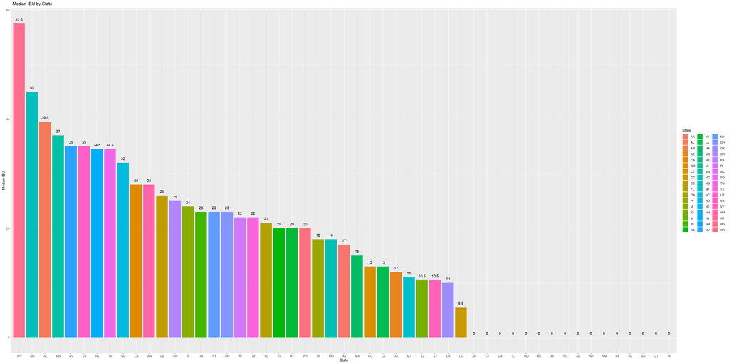

```r
g <- ggplot(IBU_Median, aes(x = reorder(State,-Median_IBU),y = Median_IBU, fill =State)) + geom_bar(stat = "identity")+ geom_text(aes(label = Median_IBU), vjust=-1) + labs(title =" Median IBU by State", x = "State", y = "Median IBU")
g
```

WV has the highest Median IBU than any other state per the results above at 57.5.

```r
Highest_AVB<- beer_breweries_df[which.max(beer_breweries_df$ABV),]
Highest_IBU <- beer_breweries_df[which.max(beer_breweries_df$IBU),]

Highest_AVB
```

|  | Brew_ID | Name.x | City | State | Name.y | Beer_ID | ABV | IBU | Style | Ounces |
| --- | --- | --- | --- | --- | --- | --- | --- | --- | --- | --- |
| 368 | 52 | Upslope Brewing Company | Boulder | CO | Lee Hill Series Vol. 5 - Belgian Style Quadrupel Ale | 2565 | 0.128 | 0 | Quadrupel (Quad) | 19.2 |

```r
Highest_IBU
```

|  | Brew_ID | Name.x | City | State | Name.y | Beer_ID | ABV | IBU | Style | Ounces |
| --- | --- | --- | --- | --- | --- | --- | --- | --- | --- | --- |
| 1721 | 375 | Astoria Brewing Company | Astoria | OR | Bitter Bitch Imperial IPA | 980 | 0.082 | 138 | American Double / Imperial IPA | 12 |

The highest Alcohol Content by Volume comes from CO with a ABV of .128 (12.8%). The beers name is Lee Hill Series Vol. 5 - Belgian Style Quadrupel Ale and is brewed by Upslope Brewing Company.

The highest IBU beer comes from OR with a IBU of 138. The beers name is Bitter Bitch Imperial IPA and is brewed by Asoria Brewing Company.

```r
summary(beer_breweries_df)
```

```
##     Brew_ID         Name.x              City              State
##  Min.   :  1.0   Length:2225        Length:2225        Length:2225
##  1st Qu.: 92.0   Class :character   Class :character   Class :character
##  Median :207.0   Mode  :character   Mode  :character   Mode  :character
##  Mean   :231.3
##  3rd Qu.:366.0
##  Max.   :558.0
##     Name.y             Beer_ID          ABV               IBU
##  Length:2225        Min.   :   5   Min.   :0.00000   Min.   :  0.00
##  Class :character   1st Qu.: 877   1st Qu.:0.05000   1st Qu.:  0.00
##  Mode  :character   Median :1495   Median :0.05600   Median : 16.00
##                     Mean   :1461   Mean   :0.05832   Mean   : 24.33
##                     3rd Qu.:2091   3rd Qu.:0.06700   3rd Qu.: 40.00
##                     Max.   :2692   Max.   :0.12800   Max.   :138.00
##     Style               Ounces
##  Length:2225        Min.   : 8.40
##  Class :character   1st Qu.:12.00
##  Mode  :character   Median :12.00
##                     Mean   :13.64
##                     3rd Qu.:16.00
##                     Max.   :32.00
```

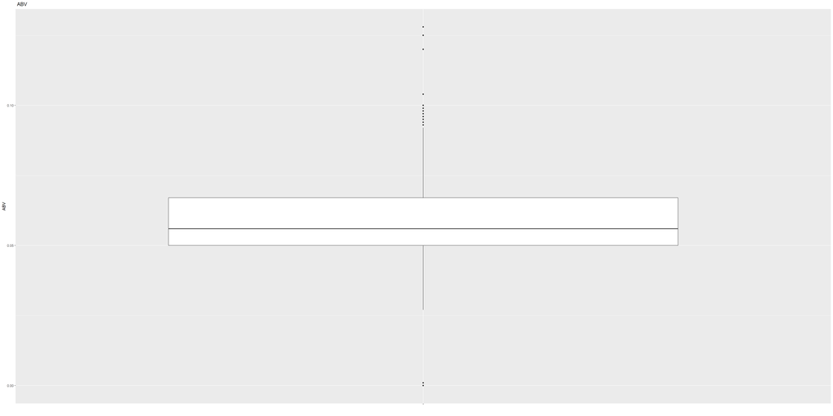

```r
ABV <- data.frame(beer_breweries_df$ABV)


ggplot(data = ABV, aes(x = "", y = beer_breweries_df.ABV)) +
  geom_boxplot() + labs(title =" ABV", x = "", y = "ABV")
```

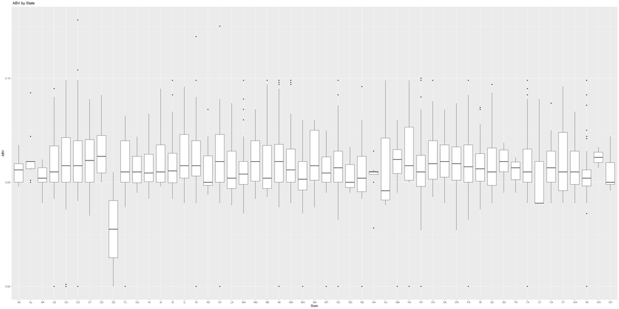

```r
ggplot(data = beer_breweries_df, aes(x = State, y = ABV)) +
  geom_boxplot() + labs(title =" ABV by State", x = "State", y = "ABV")
```

Summary statistics on ABV

Based on the data we expect to have most beers be produced between 5% to 6.7%, with the most occuring alcohol content occuring at 5.6% and a overall average of all beers at 5.82%

There are few expections on this of course, with the maximum alcohol content by volume being 12.8% and minimum being 0%. Since this is what the Market is producing today, it can mean a number of things. This is what the market is currently looking for, the current standerdized process for brewing cause most beers to have this expected alcohol content, or there are untapped potentail markets where they are looking for beers with more alcohol content.

#Dropped the zeros for the correlation

```r
beer_df_ABV_IBU <- filter(beer_breweries_df, IBU != 0)
```

#Scatter Plot of ABV and IBU

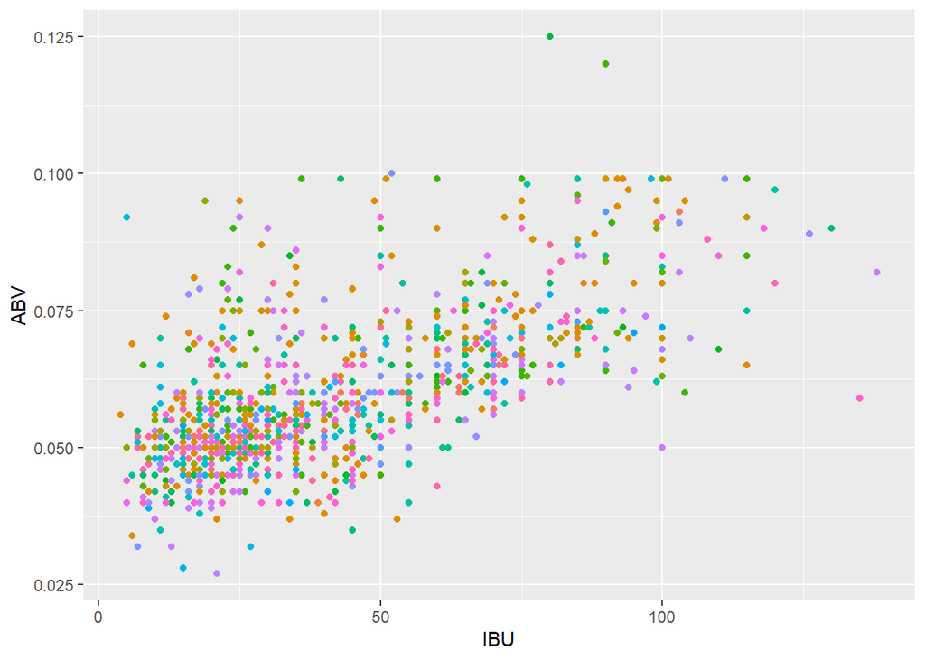

```r
IBU_ABV <- ggplot(beer_df_ABV_IBU, aes(IBU, ABV, colour = State)) +

  geom_point() +

  theme(legend.position = "none")

IBU_ABV
```

Based on the graph above. It is apprent there is a postive relationshipfor Alcohol Content and IBU. Now with that being said the large majoriity of this is cocentrated between just below 5% to 6% but there still shows a postive trend.

```r
df <-  dplyr::filter(beer_breweries_df, grepl("Ale",Style))
Ale <-  dplyr::filter(df, !grepl("IPA",Style))
IPA <-  dplyr::filter(df, grepl("IPA",Style))
IPA
```

| Brew_ID | Name.x | City | State | Name.y | Beer_ID | ABV | IBU | Style | Ounces |
| --- | --- | --- | --- | --- | --- | --- | --- | --- | --- |
| 54 | Bent Brewstillery | Roseville | MN | Moar | 2558 | 0.044 | 44 | English India Pale Ale (IPA) | 12 |
| 108 | Bonfire Brewing Company | Eagle | CO | Farmer Wirtz India Pale Ale | 1549 | 0.070 | 94 | English India Pale Ale (IPA) | 16 |
| 180 | Carolina Brewery | Pittsboro | NC | Flagship IPA | 530 | 0.057 | 0 | English India Pale Ale (IPA) | 12 |
| 211 | Temperance Beer Company | Evanston | IL | Gatecrasher | 1939 | 0.066 | 0 | English India Pale Ale (IPA) | 12 |
| 216 | Texian Brewing Co. | Richmond | TX | Brutus | 2116 | 0.071 | 69 | English India Pale Ale (IPA) | 12 |
| 253 | Santa Cruz Mountain Brewing | Santa Cruz | CA | Casinos IPA | 1362 | 0.070 | 0 | English India Pale Ale (IPA) | 16 |
| 269 | Long Trail Brewing Company | Bridgewater Corners | VT | Long Trail IPA | 1926 | 0.059 | 42 | English India Pale Ale (IPA) | 12 |
| 279 | Berkshire Brewing Company | South Deerfield | MA | Lost Sailor IPA | 1900 | 0.055 | 40 | English India Pale Ale (IPA) | 12 |
| 328 | Half Acre Beer Company | Chicago | IL | Meat Wave | 849 | 0.060 | 0 | English India Pale Ale (IPA) | 16 |
| 432 | North Country Brewing Company | Slippery Rock | PA | Paleo IPA | 1307 | 0.060 | 0 | English India Pale Ale (IPA) | 12 |

[output cut: 2 more lines]

```r
Ale
```

| Brew_ID | Name.x | City | State | Name.y | Beer_ID | ABV | IBU | Style | Ounces |
| --- | --- | --- | --- | --- | --- | --- | --- | --- | --- |
| 1 | NorthGate Brewing | Minneapolis | MN | Wall's End | 2690 | 0.048 | 19 | English Brown Ale | 16.0 |
| 1 | NorthGate Brewing | Minneapolis | MN | Pumpion | 2689 | 0.060 | 38 | Pumpkin Ale | 16.0 |
| 2 | Against the Grain Brewery | Louisville | KY | Flesh Gourd'n | 2681 | 0.066 | 21 | Pumpkin Ale | 16.0 |
| 2 | Against the Grain Brewery | Louisville | KY | Kamen Knuddeln | 2676 | 0.065 | 0 | American Wild Ale | 16.0 |
| 2 | Against the Grain Brewery | Louisville | KY | Sho'nuff | 2680 | 0.040 | 13 | Belgian Pale Ale | 16.0 |
| 2 | Against the Grain Brewery | Louisville | KY | A Beer | 2683 | 0.042 | 42 | American Pale Ale (APA) | 16.0 |
| 2 | Against the Grain Brewery | Louisville | KY | Coq de la Marche | 2677 | 0.051 | 38 | Saison / Farmhouse Ale | 16.0 |
| 4 | Mike Hess Brewing Company | San Diego | CA | Jucundus | 2666 | 0.060 | 24 | Wheat Ale | 16.0 |
| 5 | Fort Point Beer Company | San Francisco | CA | Westfalia | 2660 | 0.056 | 16 | American Amber / Red Ale | 12.0 |
| 5 | Fort Point Beer Company | San Francisco | CA | Park | 2661 | 0.047 | 19 | American Pale Wheat Ale | 12.0 |

[output cut: 865 more lines]

```r
#Use KNN to investigate the relationship between IPA and other Ales
#Find ABV and IBU for both any beer with 'Ale' in its name other than IPA and India Pale Ales (IPA)
splitPerc = .70
Ale <-beer_breweries_df %>% select(ABV,IBU) %>% filter(str_detect(beer_breweries_df$Name.x,"Ale$") | str_detect(beer_breweries_df$Name.x,"India Pale Ale$"))
head(Ale)
```

|  | ABV | IBU |
| --- | --- | --- |
| 1 | 0.051 | 25 |
| 2 | 0.072 | 70 |
| 3 | 0.050 | 30 |
| 4 | 0.049 | 0 |
| 5 | 0.068 | 0 |
| 6 | 0.043 | 0 |

```r
dim(Ale)
```

```
## [1] 7 2
```

```r
summary(Ale)
```

```
##       ABV               IBU
##  Min.   :0.04300   Min.   : 0.00
##  1st Qu.:0.04900   1st Qu.: 0.00
##  Median :0.05000   Median : 0.00
##  Mean   :0.05457   Mean   :17.86
##  3rd Qu.:0.05950   3rd Qu.:27.50
##  Max.   :0.07200   Max.   :70.00
```

```r
Ale
```

| ABV | IBU |
| --- | --- |
| 0.051 | 25 |
| 0.072 | 70 |
| 0.050 | 30 |
| 0.049 | 0 |
| 0.068 | 0 |
| 0.043 | 0 |
| 0.049 | 0 |